# Assignment 4: Methods of Moment Estimation

Ramya Pinninti

Due: February 24, 2026

## **Assignment Objectives**

- Master the fundamental concepts of point estimation and performance metrics
- Understand the theoretical foundation of the method of moments estimator (MME)
- Implement MME in R, incorporating numerical approximation methods

**Use of AI Tools**

**Policy on AI Tool Use**: Students must adhere to the AI tool policy specified in the course syllabus. The direct copying of AI-generated content is strictly prohibited. All submitted work must reflect your own understanding; where external tools are consulted, content must be thoroughly rephrased and synthesized in your own words.

**Code Inclusion Requirement**: Any code included in your essay must be properly commented to explain the purpose and/or expected output of key code lines. Submitting AI-generated code without meaningful, student-added comments will not be accepted.

**Log-logistic Distribution**

The log-logistic distribution (also known as the Fisk distribution) is a continuous probability distribution that is particularly useful in contexts where data exhibit non-negative, skewed behavior and where the hazard rate is unimodal (increases to a peak and then decreases). It has been widely used in the areas such as survival analysis and reliability engineering, environmental science, economics, pharmacology, finance and risk management, etc.

For given shape parameter $\beta$ and scale parameter $\alpha$, the cumulative distribution function

$$F(x) = \frac{1}{1+(x/\alpha)^{-\beta}}$$

As an exercise, you can derive the density in the following form

$$f(x) =
\frac{(\beta/\alpha)(x/\alpha)^{\beta-1}}{[1+(x/\alpha)^\beta]^2}, \ \
\text{ for } \ \ x > 0.$$

After some algebra, we can find the $k$th moment

$$\mu_k = E[X^k] = \alpha^k B\left(1+\frac{k}{\beta}, 1 - \frac{k}{\beta}
\right).$$

This assignment will focus on finding MME of parameters $\alpha$ and $\beta$ based on a real-world application data set.

## **Question 1: Derive the log-logistic density function**

Given the CDF of the two-parameter log-logistic distribution

$$F(x) = \frac{1}{1+(x/\alpha)^{-\beta}}.$$

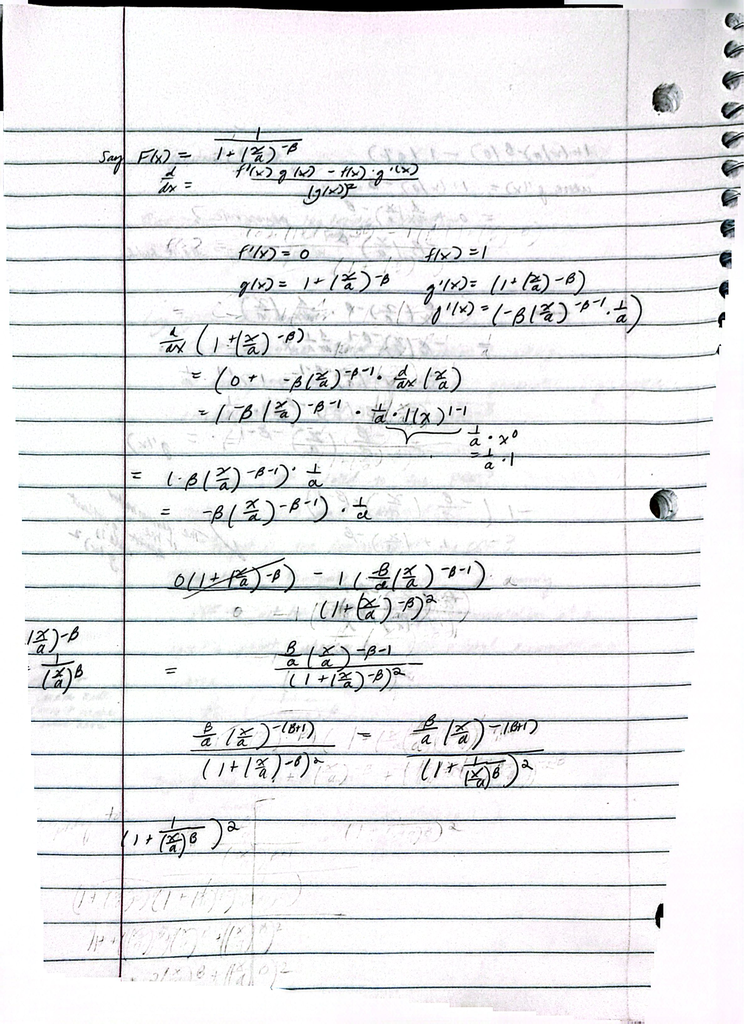

Deriving the Log-Logistic PDF

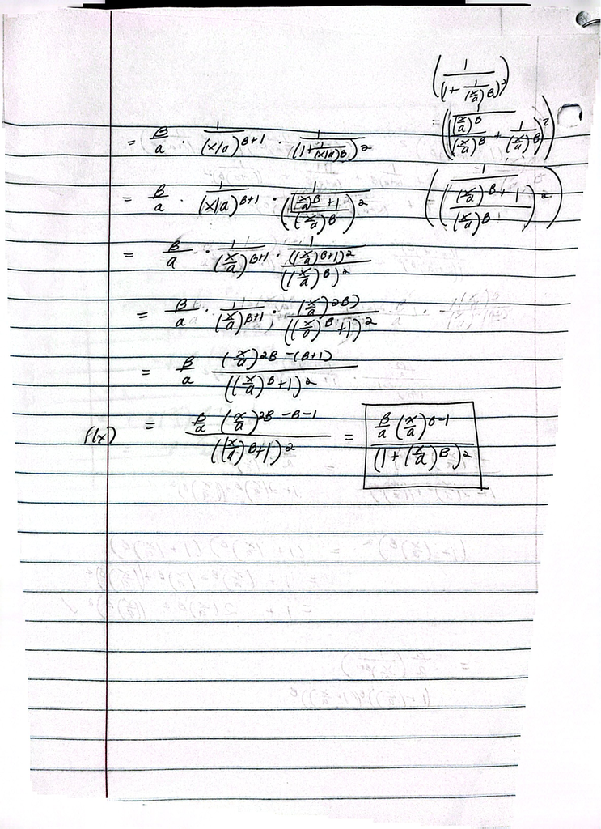

Deriving the Log-Logistic PDF

## **Question 2: Distribution of Recovery Time from A Surgery**

Time to recovery (in days) after a specific knee surgery procedure. This follows a typical **log-logistic pattern** in medical survival/recovery analysis:

```
8.23, 12.74, 14.83, 16.61, 18.16, 19.55, 20.80, 21.94, 23.00, 23.98, 24.89, 25.75, 26.56,
27.34, 28.08, 28.79, 29.48, 30.15, 30.81, 31.45, 32.08, 32.70, 33.31, 33.92, 34.53, 35.13,
35.73, 36.33, 36.93, 37.53, 38.14, 38.75, 39.37, 40.00, 40.64, 41.29, 41.95, 42.63, 43.33,
44.05, 44.79, 45.56, 46.36, 47.20, 48.08, 49.02, 50.03, 51.12, 52.32, 53.65
```

Based on the above data to perform the following analysis.

1. Using method of moment estimation to estimate $\alpha$ and $\beta$, denoted by $\hat{\alpha}$ and $\hat{\beta}$, respectively.
2. Since the moment estimates $\hat{\alpha}$ and $\hat{\beta}$ are random, construct bootstrap sampling distributions for each. To visualize these distributions, plot separate bootstrap histograms for $\hat{\alpha}$ and $\hat{\beta}$. Then, overlay a smooth density curve on each histogram using Gaussian kernel density estimation. Finally, describe the patterns of these density curves.

```r
# Given data
recovery_times <- c(8.23, 12.74, 14.83, 16.61, 18.16, 19.55, 20.80, 21.94, 23.00, 23.98, 24.89,
                    25.75, 26.56, 27.34, 28.08, 28.79, 29.48, 30.15, 30.81, 31.45, 32.08, 32.70,
                    33.31, 33.92, 34.53, 35.13, 35.73, 36.33, 36.93, 37.53, 38.14, 38.75, 39.37,
                    40.00, 40.64, 41.29, 41.95, 42.63, 43.33, 44.05, 44.79, 45.56, 46.36, 47.20,
                    48.08, 49.02, 50.03, 51.12, 52.32, 53.65)

# --- a) Method of Moments Estimation ---

mom_function <- function(params, data) {
  alpha <- params[1]
  beta <- params[2]

  if (alpha <= 0 || beta <= 2.1) return(1e10) # Beta must be > 2 for 2nd moment to exist

  # Theoretical moments
  theo_mean <- alpha * (pi/beta) / sin(pi/beta)
  theo_var2 <- alpha^2 * (2*pi/beta) / sin(2*pi/beta)

  # Sample moments
  samp_mean <- mean(data)
  samp_var2 <- mean(data^2)

  # Minimize the sum of squared differences
  return((theo_mean - samp_mean)^2 + (theo_var2 - samp_var2)^2)
}

# Initial guess: alpha is roughly the median, beta is a shape parameter
init_guess <- c(median(recovery_times), 3)
mom_fit <- optim(init_guess, mom_function, data = recovery_times)

alpha_hat <- mom_fit$par[1]
beta_hat <- mom_fit$par[2]

cat("MoM Estimates: Alpha =", alpha_hat, "Beta =", beta_hat, "\n")
```

```
MoM Estimates: Alpha = 33.55861 Beta = 7.082721
```

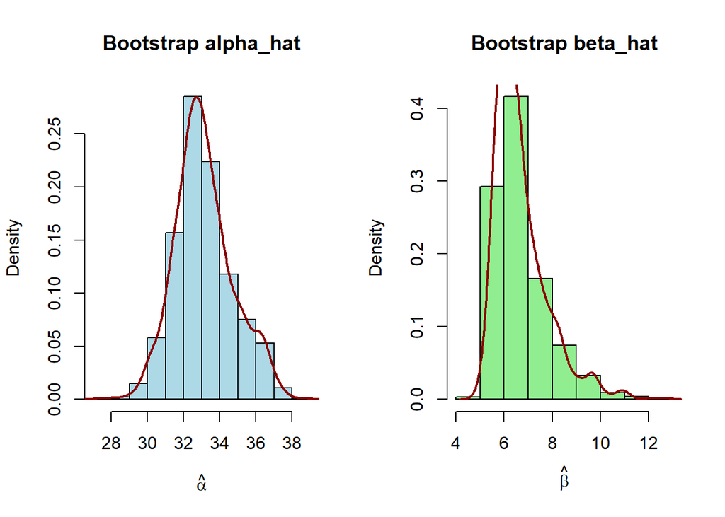

```r
# --- b) Bootstrap Sampling Distributions ---

set.seed(42)
n_bootstrap <- 1000
boot_results <- matrix(NA, nrow = n_bootstrap, ncol = 2)

for(i in 1:n_bootstrap) {
  resample <- sample(recovery_times, replace = TRUE)
  # Re-run  on the resampled data
  boot_fit <- optim(c(alpha_hat, beta_hat), mom_function, data = resample)
  boot_results[i, ] <- boot_fit$par
}

alpha_boot <- boot_results[, 1]
beta_boot <- boot_results[, 2]

# Visualization
par(mfrow = c(1, 2))

# Histogram for Alpha
hist(alpha_boot, prob = TRUE, col = "lightblue", main = "Bootstrap alpha_hat", xlab = expression(hat(alpha)))
lines(density(alpha_boot, kernel = "gaussian"), col = "darkred", lwd = 2)

# Histogram for Beta
hist(beta_boot, prob = TRUE, col = "lightgreen", main = "Bootstrap beta_hat", xlab = expression(hat(beta)))
lines(density(beta_boot, kernel = "gaussian"), col = "darkred", lwd = 2)
```

Using the bootstrap estimates for α and β, histograms were plotted. Each histogram represents the distribution of the estimates across the 1000 bootstrap samples.

A KDE was then overlayed over the histograms. The histogram and density curve for alpha represents the variability in the estimate for alpha across the samples. A narrow and symmetric curve shows low variability and a reliable estimate for the alpha value. A skewed or bimodal distribution shows more variability/uncertainty.

The distribution for beta appears right-skewed, while the curve for alpha is more symmetric, suggesting that this is a more reliable estimate.